# Project2_Dataset2

Author

Nick Weiner

## Introduction

For Project 2, our objective is to make 3 different ELT pipelines for 3 different wide-format .csv files.

## The Code

```r
library(knitr)
library(tidyverse)
library(lubridate)
```

For my data, I wanted not only to look at energy data but also population data from those countries. I felt like there could be an interesting correlation between population and energy usage. I used Claude to generate a .csv of population data that I could then join.

```r
Energy <- read.csv("electricity_production_by_country.csv")
Population <- read.csv("country_population.csv")
kable(head(Energy))
```

| Location | Total_TWh | Coal_TWh | Gas_TWh | Other_fossil_TWh | Nuclear_TWh | Hydro_TWh | Wind_TWh | Solar_TWh | Bioenergy_TWh | Other_renewables_TWh | Year |
| --- | --- | --- | --- | --- | --- | --- | --- | --- | --- | --- | --- |
| World | 31746.92 | 10491.47 | 6903.64 | 823.92 | 2813.09 | 4433.08 | 2711.33 | 2778.23 | 702.83 | 89.33 | 2025 |
| China | 10579.70 | 5773.02 | 317.94 | 88.71 | 487.35 | 1395.70 | 1135.44 | 1174.92 | 206.62 | NA | 2025 |
| United States | 4519.79 | 737.15 | 1807.34 | 31.72 | 784.78 | 241.70 | 464.39 | 388.82 | 46.19 | 17.70 | 2025 |
| India | 2081.60 | 1474.15 | 48.54 | 4.10 | 53.83 | 177.97 | 103.98 | 195.99 | 23.04 | NA | 2025 |
| Russia | 1192.79 | 219.52 | 533.17 | 14.47 | 218.65 | 199.73 | 3.64 | 2.84 | 0.77 | NA | 2025 |
| Japan | 1029.86 | 330.08 | 337.57 | 25.39 | 94.09 | 73.90 | 12.85 | 101.06 | 54.92 | NA | 2025 |

```r
kable(head(Population))
```

| Location | Year | Population |
| --- | --- | --- |
| Afghanistan | 2009 | 27466101 |
| Afghanistan | 2010 | 28284089 |
| Afghanistan | 2011 | 29347708 |
| Afghanistan | 2012 | 30560034 |
| Afghanistan | 2013 | 31622704 |
| Afghanistan | 2014 | 32792523 |

Here is the bulk of my data tidying and pivoting. I first pivoted the energy sources into their own column, and then I cleaned and organized the data. Following that, I did a left_join on the population data in order to get a full set of data that I could then manipulate.

```r
Energy1 <- Energy |>
  pivot_longer(Total_TWh:Other_renewables_TWh) |>
  mutate(Energy_Source = str_remove_all(name, "_TWh$")) |>
  select(!name) |>
  relocate(Year, Location, Energy_Source, value)|>
  rename("Value_TWh" = value)

kable(head(Energy1))
```

| Year | Location | Energy_Source | Value_TWh |
| --- | --- | --- | --- |
| 2025 | World | Total | 31746.92 |
| 2025 | World | Coal | 10491.47 |
| 2025 | World | Gas | 6903.64 |
| 2025 | World | Other_fossil | 823.92 |
| 2025 | World | Nuclear | 2813.09 |
| 2025 | World | Hydro | 4433.08 |

```r
Energy2 <- Energy1 |>
  left_join(Population,
    by = c("Location", "Year"))|>
  select(!Year)|>
  mutate(
    Value_TWh = as.integer(Value_TWh),
    Population = as.integer(Population)
  )
kable(head(Energy2))
```

| Location | Energy_Source | Value_TWh | Population |
| --- | --- | --- | --- |
| World | Total | 31746 | NA |
| World | Coal | 10491 | NA |
| World | Gas | 6903 | NA |
| World | Other_fossil | 823 | NA |
| World | Nuclear | 2813 | NA |
| World | Hydro | 4433 | NA |

The data I was most interested in was seeing how the populations intersect with the energy usage data. I made some scatter plots not only to compare Population with energy usage but also population with per capital energy usage to see if different countries had different energy efficiencies.

```r
Energy3 <- Energy2 |>
  mutate(Per_Capita_Energy_kWh = (Value_TWh/Population)*1e9)|>
  filter(!is.na(Population)) |>
  filter(!is.na(Per_Capita_Energy_kWh)) |>
  filter(Energy_Source == "Total")

kable(head(Energy3))
```

| Location | Energy_Source | Value_TWh | Population | Per_Capita_Energy_kWh |
| --- | --- | --- | --- | --- |
| China | Total | 10579 | 1406585000 | 7521.053 |
| United States | Total | 4519 | 341784857 | 13221.768 |
| India | Total | 2081 | 1463865525 | 1421.579 |
| Russia | Total | 1192 | 143513328 | 8305.849 |
| Japan | Total | 1029 | 123366734 | 8340.984 |
| Brazil | Total | 750 | 212812405 | 3524.231 |

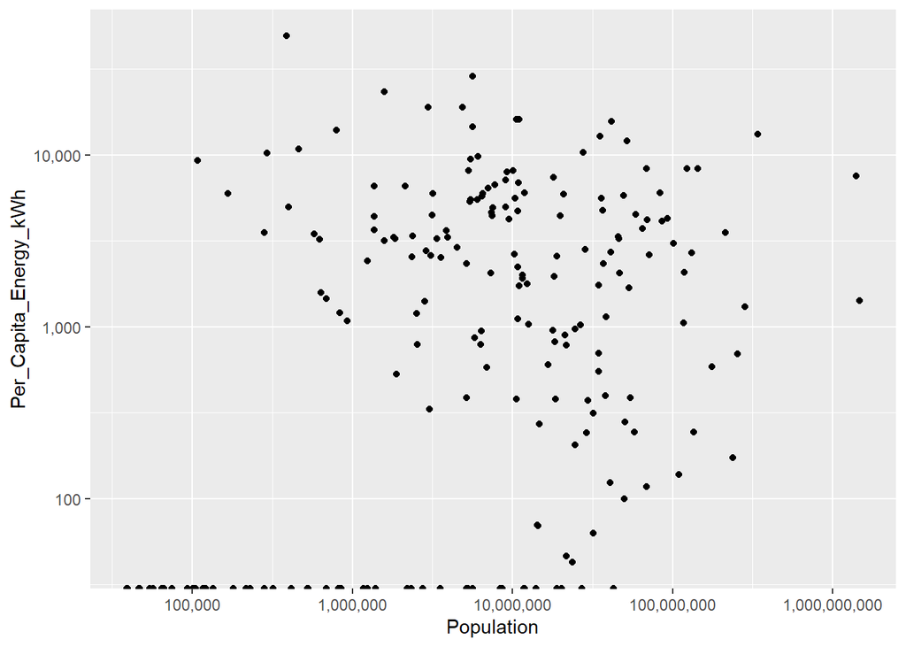

```r
ggplot(data = Energy3, aes(x = Population, y = Per_Capita_Energy_kWh)) + geom_point() +
  scale_x_log10(labels = scales::comma) +
  scale_y_log10(labels = scales::comma)
```

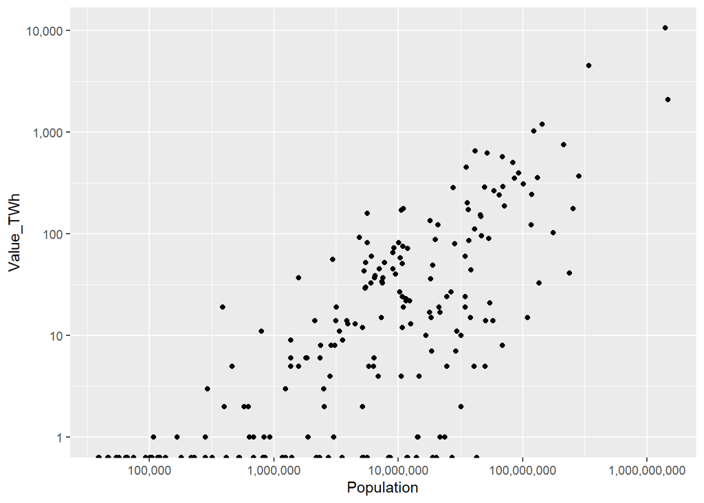

```r
ggplot(data = Energy3, aes(x = Population, y = Value_TWh)) + geom_point() +
  scale_x_log10(labels = scales::comma) +
  scale_y_log10(labels = scales::comma)
```